# Lecture 1 Exercises

## Short Questions

1. What is the difference between a list and an array?
2. Consider the list

`list_colors = ["red","yellow","green"]`

What is the output of `list_colors[0]` and  
`list_colors[1]`?

3. How do you concatenate two strings?
4. What does the error "not defined" mean?
5. What does the error "could not be broadcast" mean?
6. How do you compute the median of an array?

```python
# Write your answers here as comments:

#Answer 1: A list can consist of elements of different data types. However, an array can only consist of elements of the same data type.

#Answer 2: The output of list_colors[0]: red ; the output of list_colors[1]: yellow.

#Answer 3: Just use "+". for example, "apple" + "red".

#Answer 4: The variable or command that you input in the code chunk is defined unclearly or not defined. For example, don't include quotation marks.

#Answer 5: It means the arrays have incompatible shapes. For example, when doing matrix multiplication with the numpy package,
# if the two matrices have different values of their trailing dimensions (the two arrays have incompatible shapes), it will lead to the occurrence of this error.

#Answer 6: Import the numpy package, and use np.median() command to calculate the median of an array.
```

## Long Questions

(a) Import the pandas and matplotlib packages

```python
import pandas as pd
import matplotlib.pyplot as plt
```

(b) Open the dataset "worldbank_wdi_2019.csv"  
in the "data" folder

- Read it as a pandas object called "wdi"
- Note: This is a subset of the World Development Indicators for 2019
- Each observation represents a different country

```python
wdi = pd.read_csv("data/worldbank_wdi_2019.csv")
```

(c) Browse the dataset and manually create  
a list of variable names

```python
# Create a list, e.g. "variable_names = [ "name1", "name2", "name3" ]"
# Manually type the names of the variables
# If you're viewing the dataset from the VS-Code "Variables" tool, you'll
# see an extra column "index". Do not include this in your list.

variable_names = ["year", "country_name", "life_expectancy", "gdp_per_capita_usd"]
```

(d) Compute descriptive statistics for the fourth  
variable in the dataset

- One way to do this is:

wdi["gdp_per_capita_usd"].describe()

- Do something similar, but with the list you created above.
- Substitute "gdp_per_capita_usd" with a command that

automatically extracts the fourth element in the list

```python
# Remember that the numbering in Python starts at zero
# For example:
# list_colors = ["red","green","yellow"]
# list_colors[2] will output "yellow"

wdi["gdp_per_capita_usd"].describe()
```

```
count       255.000000
mean      17230.949757
std       25792.183785
min         216.972968
25%        2186.046581
50%        6837.717826
75%       19809.323135
max      199377.481800
Name: gdp_per_capita_usd, dtype: float64
```

```python
# Substitute "gdp_per_capita_usd" with a command that automatically extracts the fourth element in the list
wdi[variable_names[3]].describe()
```

```
count       255.000000
mean      17230.949757
std       25792.183785
min         216.972968
25%        2186.046581
50%        6837.717826
75%       19809.323135
max      199377.481800
Name: gdp_per_capita_usd, dtype: float64
```

(e) Show a scatter plot that shows "gdp_per_capita_usd"  
in the x-axis and "lifexpectancy" in the y-axis. Label the axes.

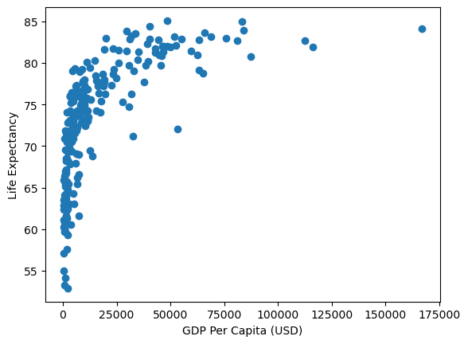

```python
plt.scatter(x=wdi["gdp_per_capita_usd"],y=wdi["life_expectancy"])
plt.xlabel("GDP Per Capita (USD)")
plt.ylabel("Life Expectancy")
plt.show()
```

(f) Generate "vec_x" from a chi-square  
distribution with (df = 1, size = 1000)

- Plot a histogram of each variable, with axis labels, and title
- Create a new variable "vec_y" by the formula

$ y = e^x + 2x + 5$

- Plot "vec_x" against "vec_y" and label the axes

```python
import numpy as np

np.random.seed(888)

vec_x = np.random.chisquare(df=1, size=1000)

# Create a new variable vec_y
e = np.exp(1)
vec_y = e**vec_x+2*vec_x+5
```

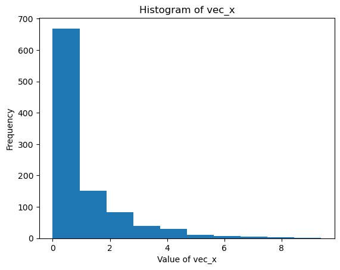

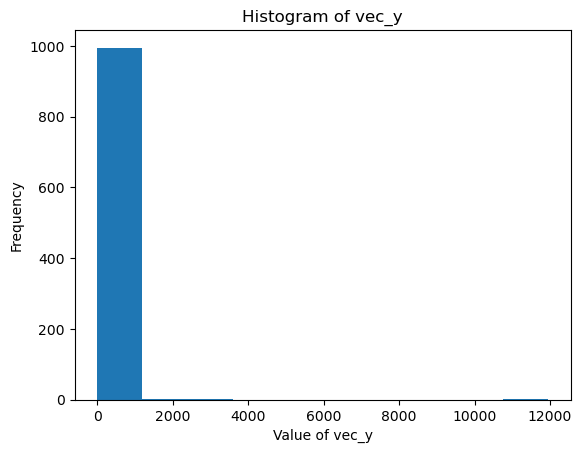

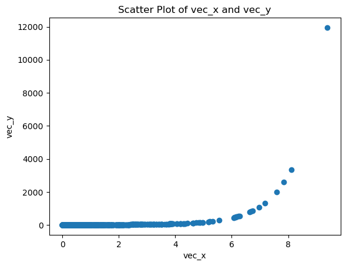

```python
# Figures
plt.hist(vec_x)
plt.xlabel("Value of vec_x")
plt.ylabel("Frequency")
plt.title("Histogram of vec_x")
plt.show()

plt.hist(vec_y)
plt.xlabel("Value of vec_y")
plt.ylabel("Frequency")
plt.title("Histogram of vec_y")
plt.show()

plt.scatter(x=vec_x,y=vec_y)
plt.xlabel("vec_x")
plt.ylabel("vec_y")
plt.title("Scatter Plot of vec_x and vec_y")
plt.show()
```

(g) Research online how to create an array with  
`size = 1000` entries, with all entries equal to one.

- Create a new matrix, `X_mat` that appends a

vector with only ones and "vec_x" from question (f) to form  
a matrix with two columns and 1000 rows

- Compute $(X_{mat}'X_{mat})^{-1}$

```python
# Create a new matrix
newarray = np.ones(1000)
X_mat = np.column_stack([newarray,vec_x])

# Calculation
X_mat_transpose = np.matrix.transpose(X_mat)
X_mat_mul=np.matmul(X_mat_transpose,X_mat)
X_inv = np.linalg.inv(X_mat_mul)
print(X_inv)
```

```
[[ 0.0015456  -0.00054897]
 [-0.00054897  0.00055235]]
```